# RemoteTransform2D

# RemoteTransform2D pushes its transform to another node

A `RemoteTransform2D` moves, scales, and rotates a target `Node2D` to match its own transform data.

You can use it whenever you need two nodes to move together but they’re in different places in the scene tree.

This problem is both common and highly contextual: it entirely depends on your game’s code structure. While we give you some examples in this guide, you’ll likely find more opportunities to use `RemoteTransform2D` in your own projects.

In this guide, you will learn:

- How to synchronize two nodes’ transforms using `RemoteTransform2D`.
- How to set up and use the key features of `RemoteTransform2D`.
- How to use it in practice to attach UI to characters, create a map view, and more.

Contents:

- Setting up a RemoteTransform2D
- RemoteTransform2D’s key features
  - Moving nodes without parenting them
  - Updating a node’s position only
- How to use a RemoteTransform2D in practice
  - Picking up balls with a robotic claw
  - Placing UI on a rotating player
  - Locking a crosshair to enemies
  - Riding a Path2D Zipline
  - Creating a minimap
- Your questions
  - How do I transform a Control node with RemoteTransform2D?
  - How do I set a remote path through code?
  - How do I switch between two RemoteTransform2D nodes targeting one node?
  - What do I do if my target node is deleted?
- Troubleshooting
- Pro Tips
  - Smoothly transitioning a node’s properties.
  - Alternatives to using a RemoteTransform2D

## Setting up a RemoteTransform2D

A `RemoteTransform2D` needs the following to work as intended:

1. The `RemoteTransform2D` itself.
2. A node that extends `Node2D` to be the target, like a `Sprite`.
3. The `RemoteTransform2D`’s `remote_path` property set to the target `Node2D`.

This is what a `RemoteTransform2D` looks like when set up to move, rotate, and scale a distant `Node2D`.

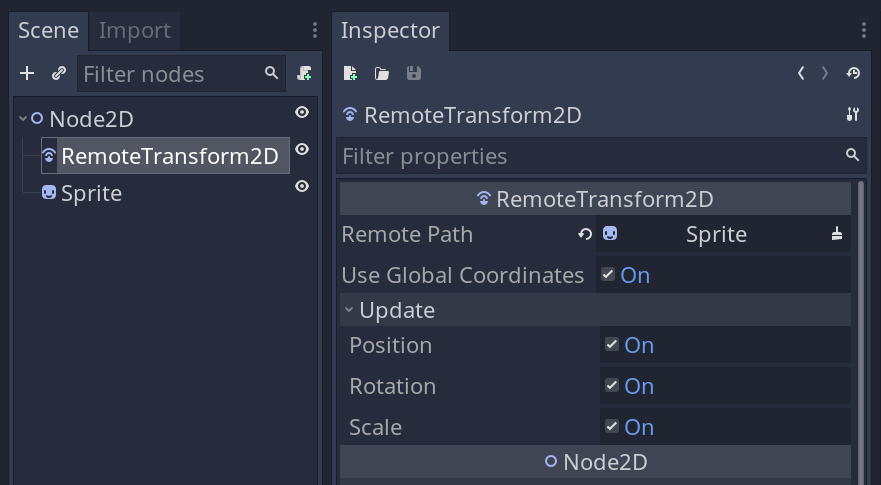

By default, a `RemoteTransform2D` node will throw a node configuration warning in the editor: “Path property must point to a valid `Node2D` node to work.” This is fine when we’re planning to assign the `remote path` in code, instead of the *Inspector*.

## RemoteTransform2D’s key features

The key features of a `RemoteTransform2D` are in its properties.

### Moving nodes without parenting them

The main feature of a `RemoteTransform2D` is that it can move, rotate, or scale a `Node2D` from anywhere in the scene tree using the `remote_path` property.

To set the *Remote Path* property, go to the *Inspector* and click *Assign*. Choose the node in the current scene you’d like to move and click *OK*.

You can also assign `remote_path` in code with a `NodePath` pointing to your target node. The path can be absolute from the scene root: `NodePath("/root/Node2D/Player")` or relative to the `RemoteTransform2D`: `NodePath("./../SibilingNode")`.

We will cover this in more detail when we use a `RemoteTransform2D` in practice.

### Updating a node’s position only

By default, a `RemoteTransform2D` sends its entire transform properties to the target node: position, rotation and scale.

The `update_position`, `update_rotation` and `update_scale` properties filter the transform data applied to the target node. You can use any combination of these three properties.

## How to use a RemoteTransform2D in practice

Here are some concrete use cases for a `RemoteTransform2D`.

### Picking up balls with a robotic claw

In this example, you will learn how to move rigid bodies with a `RemoteTransform2D`. Here, we have a claw that picks up and moves balls to the other side of the screen.

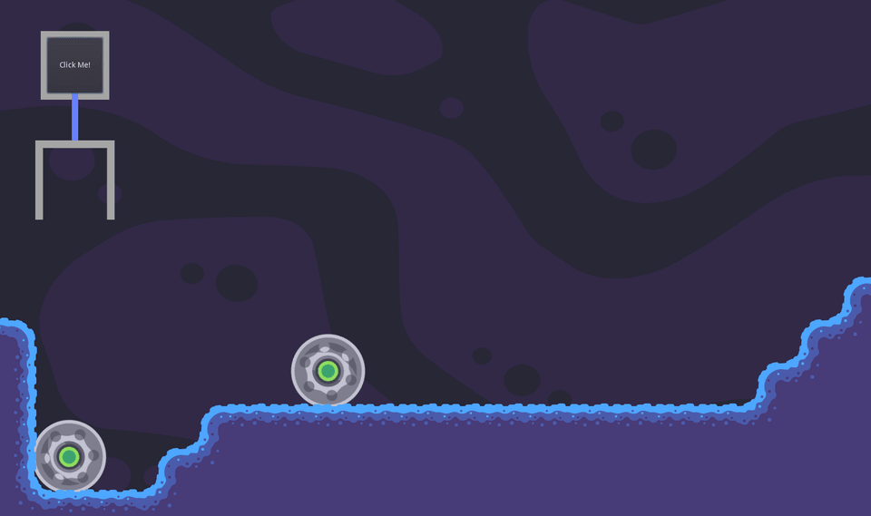

Since `RemoteTransform2D` can only update the transform data, we will need other nodes to detect when a physics body is near.

We need the functionality of the following nodes for the claw:

- `Button` to activate the claw.
- `Area2D` and a shape node to detect rigid bodies
- `RemoteTransform2D` to move the body once it’s found.
- `AnimationPlayer` to move the claw.
- `Line2D` to connect the claw’s base and arm.
- `Sprite` for each part, to see their current position on-screen.

[figure not shown]

Outside of the claw, we need a ball to pick up. We went with a `RigidBody2D` with a `CollisionShape2D` and a `Sprite`.

We went for a `RigidBody2D` instead of a `KinematicBody2D` for the ball, so it could use the physics engine to roll down the slope.

The code-ready scene looks like this:

[figure not shown]

If any physics bodies return to their starting place when dropped, you can deselect the `update_*` properties you’re not using. This often helps `RemoteTransform2D` nodes play nicer with 2D physics and will help prevent this.

Let’s set up references to different parts of the claw.

```
extends Node2D

onready var _claw: Area2D = $Claw
onready var _arm: Line2D = $Arm

onready var _remote: RemoteTransform2D = $Claw/RemoteTransform2D
onready var _animation_player: AnimationPlayer = $AnimationPlayer

onready var _button: Button = $Button


# We use `_process()` only to update the line, to make the arm and base look
# connected.
func _process(_delta: float) -> void:
    _arm.points[1] = _claw.position
```

First, we want to create a function to pick up a ball.

When you change `RigidBody2D`’s mode to *Kinematic*, the `RigidBody2D` doesn’t move automatically with the physics system anymore.

Instead, it behaves like a `KinematicBody2D`: you can still move it with code.

In this demo, we have multiple balls, so our grabbed ball will collide with the other balls as it moves with the `RemoteTransform2D`.

This can lead to some of the balls getting pushed through the walls. To prevent this, we turn off collisions for the ball grabbed by the claw.

```
func pickup(body: RigidBody2D) -> void:
    var is_busy: bool = _animation_player.current_animation == "move_base" or _remote.remote_path != ""
    if is_busy or not body.is_in_group("ball"):
        return
    # Setting the mode to kinematic allows us to control the body's position.
    body.set_deferred("mode", RigidBody2D.MODE_KINEMATIC)
    # We turn off collisions for the ball.
    body.collision_layer = 0
    body.collision_mask = 0
    _remote.remote_path = body.get_path()
```

Now we can change the body’s mode back to *Rigid* to interact with physics again.

We also set the grabbed ball’s `linear_velocity` to zero; otherwise it will fall out of our claw unnaturally fast.

Lastly, this function clears the `RemoteTransform2D`’s `remote_path`, so it’s ready for a new target.

We call the `drop()` function from the `AnimationPlayer`, using a method call track.

```
func drop() -> void:
    var body: RigidBody2D = get_node(_remote.remote_path)
    if body == null:
        return
    # We set the mode back to rigid so the ball falls and rolls, and we reset its collisions.
    body.set_deferred("mode", RigidBody2D.MODE_RIGID)
    body.linear_velocity = Vector2.ZERO
    body.collision_layer = 1
    body.collision_mask = 1
    _remote.remote_path = ""
```

Lastly, we connect the `Area2D`’s `body_entered` signal to `pickup()` and the `Button`’s `pressed` signal to start animations.

```
func _ready() -> void:
    _button.connect("pressed", self, "animate_claw")
    _claw.connect("body_entered", self, "pickup")

# As you saw in pickup
func animate_claw() -> void:
    # Using the `queue()` function on the AnimationPlayer lets us play two
    # animations in sequence as soon as the first finishes.
    _animation_player.queue("move_claw")
    _animation_player.queue("move_base")
```

Using animations to move the claw saves us some code. Editing the endpoint of the claw’s movement is also easier in the `AnimationPlayer`.

### Placing UI on a rotating player

Sometimes, you’ll want UI elements, such as life bars, to attach to characters and follow them around the game world.

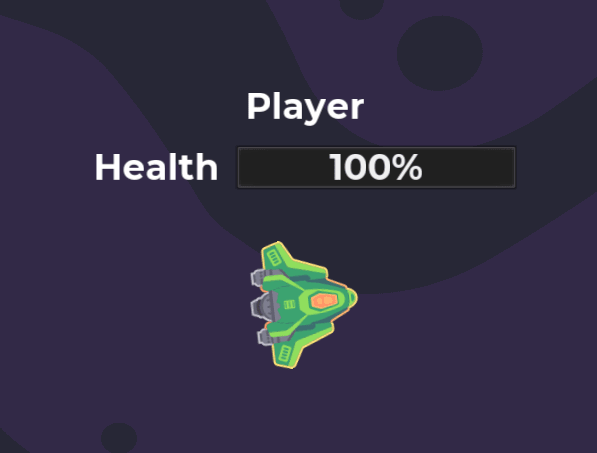

You could add them as a child of the characters, but this can cause sorting issues. Especially as `Control` nodes don’t offer a *Z Index* property, unlike 2D nodes.

Instead, you may add a `RemoteTransform2D` as a child of the characters and push their transform to bars placed in a different `CanvasLayer`, in another branch of your scene tree.

However, `RemoteTransform2D` only accepts paths to a `Node2D`.

`Control` nodes for UI appear gray when assigning a remote node in the *Inspector*.

To move a `Control` node to a `RemoteTransform2D`, you can add a new `Node2D` and make the `Control` node its child.

Here’s an example of such a scene.

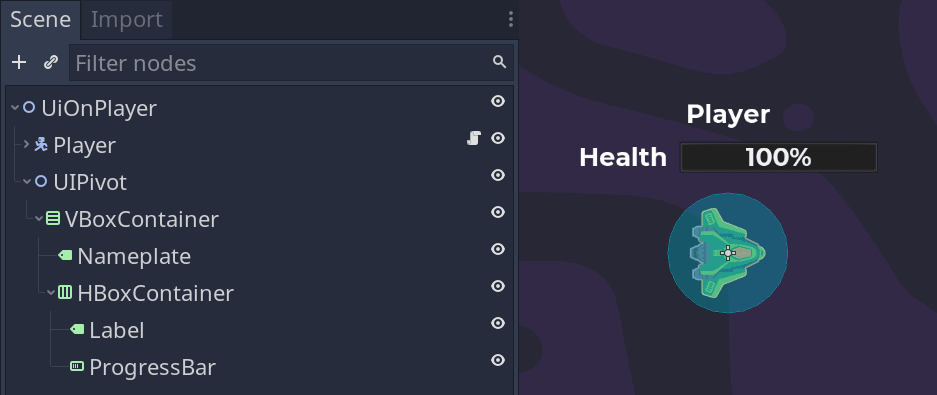

To lock rotation and scaling, disable the *Update Rotation* and *Update Scale* properties on the `RemoteTransform2D` to only update the UI’s position.

### Locking a crosshair to enemies

Here, we look at creating a lock-on icon. It’s something you’ll see in space shooters and other action games.

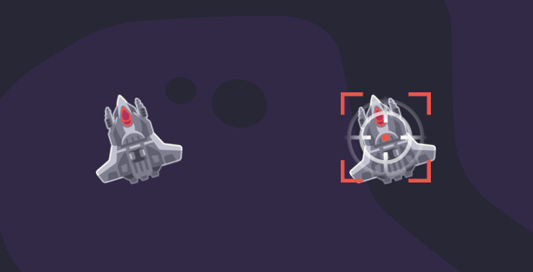

In this demo, we want a lock-on icon to follow the mouse and to snap onto a ship when it gets close to the mouse.

When we’re not locking onto an enemy ship, the icon should follow the mouse.

`RemoteTransform2D` nodes are a great fit here, as they allow us to keep the enemies and the lock-on icon decoupled.

Our scene contains:

- An `Area2D` with a `RemoteTransform2D` child. We use it to detect what’s close to the mouse.
- A `Sprite` for our lock-on icon, separate from the `Area2D`.
- Some enemy ships that have a `RemoteTransform2D` node as their child.

The game’s enemies are part of a group called “enemy,” and all `RemoteTransform2D` nodes are in a group called “remote.”

[figure not shown]

First, we move the `Area2D` to the mouse every frame. In our demo, we do that from a parent class.

```
onready var _mouse_area: Area2D = $MouseFollow

func _process(_delta: float) -> void:
    _mouse_area.set_position(get_local_mouse_position())
```

```
onready var _crosshair_path := $Crosshair.get_path()

func _ready() -> void:
    _mouse_area.connect("body_entered", self, "lock_onto_enemy")

func lock_onto_enemy(body: Node) -> void:
    if body.is_in_group("enemy") and not body.enemy_remote.remote_path:
        reset_remote_paths()
        # Give the enemy's remote the crosshair's path. This moves the crosshair to the enemy.
        body.enemy_remote.remote_path = _crosshair_path
```

Inside this connected function, the `body` argument reports which node entered the area.

If the `body` is in the “enemy” group, and it’s not already grabbing our crosshair (by having an empty `enemy_remote.remote_path`) then we can let it grab the crosshair.

**Note:** We named the enemy’s `RemoteTransform2D` `enemy_remote` because `remote` is a reserved keyword for networking in GDScript.

To release the lock-on, we use a function that resets all remote transform paths. To do so, you set the `RemoteTransform2D.remote_path` to `""` or an empty `NodePath()`.

```
func reset_remote_paths() -> void:
    for remote_node in get_tree().get_nodes_in_group("remote"):
        remote_node.remote_path = ""
```

Now we can start to move the crosshair to different `RemoteTransform2D` nodes.

To move the crosshair back to our mouse by pressing a button, we can call `reset_remote_paths()` and re-assign the mouse’s remote to our crosshair.

This example does it in `_unhandled_input()`.

```
func _unhandled_input(event: InputEvent) -> void:
    if event.is_action_pressed("interact"):
        reset_remote_paths()
        _mouse_area_remote.remote_path = _crosshair_path
```

### Riding a Path2D Zipline

In this example, we use a combination of `Path2D`, `PathFollow2D`, `Area2D`, and `RemoteTransform2D` to move a character along a zipline.

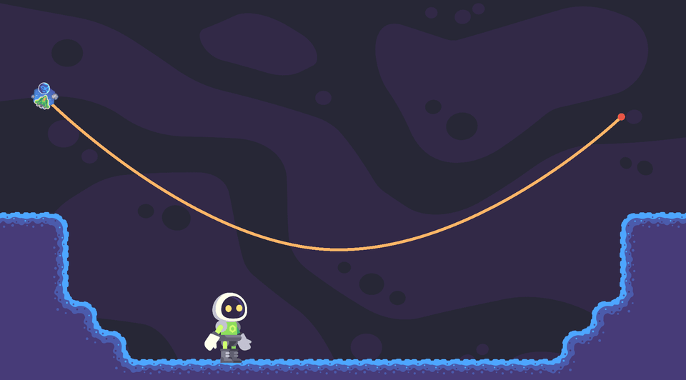

When `PathFollow2D` is combined with a `RemoteTransform2D`, it becomes a quick way to attach and remove any 2D object to a `Path2D`’s curve. You can use it for grinding rails in extreme sports games or riding ziplines in 2D platformers.

Our demo relies on:

1. A `Path2D` node with a `PathFollow2D` child. We use this to represent the zipline.
2. An `Area2D` with a `Sprite` as a child of `PathFollow2D`. We use this to detect when the player grabs the zipline.

Our scene looks like this:

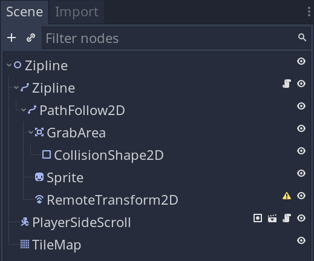

We’ll use a `body_detached` signal to let the body know that it can resume its physics process. This signal will be connected to the body later, once it’s been grabbed.

```
tool
extends Path2D

## Emitted when the body detached from the zipline.
signal body_detached

## Speed at which the zipline moves in pixels per second.
const SPEED := 1600.0

# We use the following four properties to draw the zipline.
const CURVE_THICKNESS := 8.0
const CIRCLE_RADIUS := 10.0

export var curve_color := Color.white
export var circle_color := Color.white

onready var _path_follow: PathFollow2D = $PathFollow2D
onready var _remote_transform: RemoteTransform2D = $PathFollow2D/RemoteTransform2D
onready var _grab_area: Area2D = $PathFollow2D/GrabArea

## Direction in which the body should move along the zipline.
## We use it to know when we reached the desired end of the path.
var _direction: float


func _ready() -> void:
    # We use physics process to move the grabber and character along the path.
    # We only want processing on when a character is grabbing the zipline.
    set_physics_process(false)
```

The zipline is drawn using Godot’s overridable `draw()` function, and the `tool` keyword makes it update in the editor as well. You can adjust the curve and the visual preview will update.

Drawing the zipline could be done using a `Line2D` as well, we chose to use `draw()` instead so we can add other details like circles on the zipline ends.

```
## Draw the zipline with two circles on either end and a curve connecting them.
func _draw() -> void:
    var points := curve.get_baked_points()
    draw_polyline(points, curve_color, CURVE_THICKNESS)
    draw_circle(points[0], CIRCLE_RADIUS, circle_color)
    draw_circle(points[-1], CIRCLE_RADIUS, circle_color)
```

With the drawing out of the way, we can look at how to move along our zipline.

The two functions that drive this zipline are `attach_body_to_zipline()` and `detach_from_zipline()`. When a body grabs the zipline, we want the remote transform to take control and move it.

We also need to know the body’s current direction to move the zipline. We did this by attaching a script to our side-scrolling character and defined a `get_look_direction()` function there.

```
## Attaches a body to the zipline and starts moving it towards the end of the line.
func attach_body_to_zipline(body: KinematicBody2D) -> void:
    _remote_transform.remote_path = body.get_path()
    # This tells us in which direction the zipline should move and when it
    # reaches the end.
    _direction = body.get_look_direction()
    # We move the attached body in _physics_process().
    set_physics_process(true)
    # To make this work, we need the body to stop moving on its own. Here, we
    # achieve that by turning off its _physics_proccess().
    body.set_physics_process(false)
    if body.has_method("play_zipline_animation"):
        body.play_zipline_animation()
    # Finally, we connect our body_detached signal to turn physics process on again.
    #
    # The CONNECT_ONESHOT parameter will make sure this signal is disconnected when
    # we emit the signal. Otherwise it'd still be connected to previous used bodies.
    connect("body_detached", body, "set_physics_process", [true], CONNECT_ONESHOT)


## Detaches the currently attached body from the zipline.
func detach_from_zipline() -> void:
    _remote_transform.remote_path = ""
    set_physics_process(false)
    # With our signal connection in attach_body_to_zipline(), this triggers the
    # body's processing back on.
    emit_signal("body_detached")
```

Now we can use `_unhandled_input()` to check if we’re pressing “interact.”

It will also check overlapping bodies with the `Area2D` and if they are in the “player” group.

We wrote this script so that pressing “interact” again during the zipline detaches the player.

```
func _unhandled_input(event: InputEvent) -> void:
    if not event.is_action_pressed("interact"):
        return

    # When the player presses "interact", we either detach the body from the zipline or we try to find and attach one using our Area2D.
    if is_physics_processing():
        detach_from_zipline()
    else:
        var bodies := _grab_area.get_overlapping_bodies()
        for body in bodies:
            if body.is_in_group("player"):
                attach_body_to_zipline(body)
                break


func _physics_process(delta: float) -> void:
    # Changing the PathFollow2D node's offset moves it along the parent Path2D
    # curve automatically.
    _path_follow.offset += delta * SPEED * _direction
    if did_reach_end():
        detach_from_zipline()
```

Lastly, we can see if the zipline is done by checking the *Unit Offset* of the `PathFollow2D`. Its *Unit Offset* will be `0.0` at the start, and `1.0` at the end. When combined with the direction variable, we can tell when the `PathFollow2D` has reached the end.

```
## Checks if the body reached the end of the zipline towards which it was moving.
func did_reach_end() -> bool:
    return (
        (_direction < 0.0 and is_zero_approx(_path_follow.unit_offset))
        or (_direction > 0.0 and is_equal_approx(_path_follow.unit_offset, 1.0))
    )
```

Since *Unit Offset* doesn’t round itself to `0.0` or `1.0` when it’s close to the ends, it can get stuck sometimes due to floating point precision errors. We chose to use `is_equal_approx()` in our comparisons to avoid this.

### Creating a minimap

You can use the `RemoteTransform2D` to draw a map synchronized with your game world. The map displays your player, enemies, and anything you want moving in real-time.

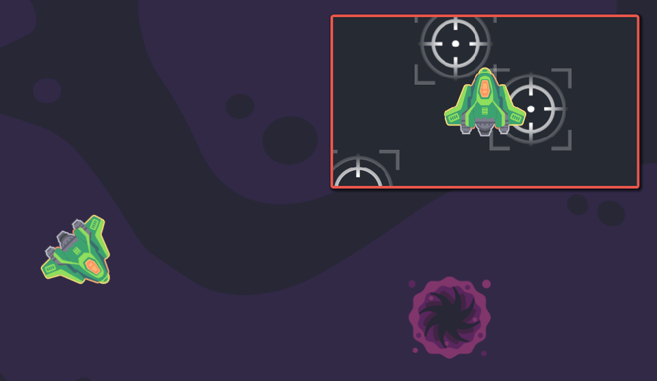

To create the map from an existing game level, we:

1. Create a `Viewport` that will render the map to a texture.
2. For each game entity to draw on the map, we:
   1. Create and inject a `RemoteTransform2D` node as a child of it. We can do that with five lines of code.
   2. Create an icon in our `Viewport` and link it with the `RemoteTransform2D` we just created.
3. We also add a `RemoteTransform2D` as a child of the world’s camera and create a proxy for it in our map’s viewport.
4. We render the `Viewport` with a parent `ViewportContainer` node as part of our user interface.

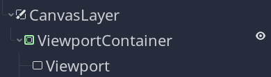

You can display the final map however you want, be it overlaid on the screen, in a box and the bottom right corner, or taking the entire screen, as we did in our space game *Harvester*.

That depends entirely on the size of the `ViewportContainer`.

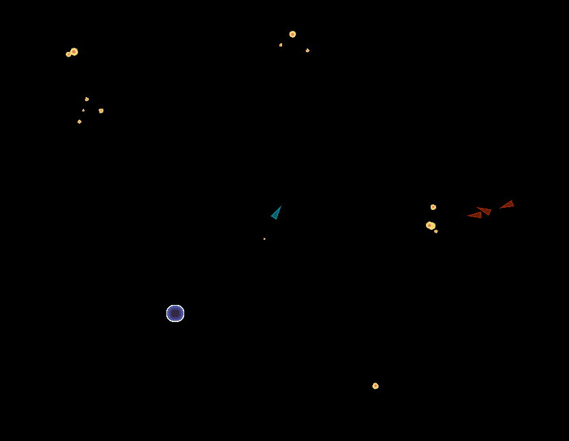

*An image of the map view in the GDquest game “Harvester”*

In our example, all nodes displayed on the map are part of a “map” node group. You can see circle-in-square group icon below.

[figure not shown]

The *MapViewport* script defines two functions: the first function adds a camera proxy, and the other populates the map with icons.

The `add_camera_proxy()` function creates a camera that follows the game world’s camera but zoomed out.

```
extends Viewport

const PLAYER_TEXTURE := preload("res://common/Player/player.png")
const ICON_TEXTURE := preload("res://common/crosshair.png")

# Path to the camera the map should follow.
export var world_camera_path: NodePath
# The zoom level we use for the map's camera. The larger the value, the more it zooms out and the more of the map appears.
export var zoom_factor := 8.0

## Adds a camera to the map's viewport that follows the `world_camera`.
func add_camera_proxy(world_camera: Camera2D) -> void:
    var camera := Camera2D.new()
    add_child(camera)
    camera.current = true
    # To view far away on the map, we change its camera's zoom. You can let the player control this zoom to view more or less of the map.
    camera.zoom = zoom_factor * Vector2.ONE

    # We create a `RemoteTransform2D` and inject it as a child of the game world's camera, to synchronize our map's camera with it.
    var remote_transform := RemoteTransform2D.new()
    world_camera.add_child(remote_transform)
    remote_transform.remote_path = camera.get_path()
```

The `populate()` function finds all the nodes in the “map” node group and creates a sprite for them on the map.

For each node, it calls an `add_icon_to_map()` function that adds one icon to the map. You can connect a signal to this function to register new icons later.

For instance, when spawning monsters.

```
## Creates an icon on the map for every node in the `map` group.
func populate_map() -> void:
    var nodes_to_track := get_tree().get_nodes_in_group("map")
    for node in nodes_to_track:
        add_icon_to_map(node)


## Adds a sprite to the map that represents and tracks an entity in the game world.
func add_icon_to_map(node_to_track: Node2D) -> void:
    var sprite := Sprite.new()

    sprite.texture = PLAYER_TEXTURE if node_to_track is Player else ICON_TEXTURE
    add_child(sprite)
    # Scaling the sprite by our camera's zoom factor makes it preserve its size on the screen. Otherwise, it'll be small and aliased.
    sprite.scale = zoom_factor * Vector2.ONE

    # Here is where we inject a `RemoteTransform2D` as a child of the world's entity.
    var remote_transform := RemoteTransform2D.new()
    # We want to control the icon's scale ourselves so we set the remote transform not to push its parent's scale to the sprite.
    remote_transform.update_scale = false
    node_to_track.add_child(remote_transform)
    remote_transform.remote_path = sprite.get_path()
    # When the node in the world is freed, the `RemoteTransform2D` will be freed too.
    # The following line will let you destroy the paired icon as well.
    remote_transform.connect("tree_exited", sprite, "queue_free")
```

Finally, we use a trick in its `_ready()` function to make the node work regardless of its position in the scene tree.

```
func _ready() -> void:
    # To ensure the camera's available, we wait for the owner of this scene to be ready.
    # We could also use get_tree().root to wait for the camera, regardless of its position in the tree.
    yield(owner, "ready")
    # We wait for the owner node to be ready to ensure the camera is part of the scene tree.
    var world_camera: Camera2D = get_node(world_camera_path)
    # We then add a camera for the map view that follows the main camera, and populate the map with icons.
    add_camera_proxy(world_camera)
    populate_map()
```

That way, you can add a new icon every time you spawn a relevant entity in the game.

You can learn more about viewports and what you can do with them in the dedicated guide: Viewport.

This approach to maps has some advantages:

- The icons on the map automatically move and rotate like entities in the game world.
- It is one of the approaches that requires the least setup.
- As you rely on the built-in `RemoteTransform2D` node, the update code uses fast compiled C++. The performance is probably better than updating everything in GDScript.
- You can use the camera’s zoom to see more or less of the world on the map.

It has one main con:

- The map view mirrors your game world. You cannot easily limit the position of sprites to the edges of the map to indicate the direction of an NPC or landmark.

As a result, using a `RemoteTransform2D` node may work best for large map views, like the fullscreen zoomed-out space view in our space game demo, [Harvester](https://github.com/GDQuest/godot-2d-space-game).

## Your questions

### How do I transform a Control node with RemoteTransform2D?

Normally, a `RemoteTransform2D` will only accept paths to a node that extends `Node2D` as a `remote_path`. If you want to move a `Control` node to a `RemoteTransform2D`, the `Control` node needs a `Node2D` parent to transform it.

Once the `Control` node has a `Node2D` parent, you can adjust the `Control`’s `rect_position`, `rect_rotation` and `rect_scale` to fine-tune its transformation relative to the `Node2D` target.

### How do I set a remote path through code?

You can set a remote path through code in a few ways. The easiest way is to get a reference to the node you want as the remote node, then call `get_path()` to get its absolute path.

You can use `RemoteTransform2D.get_path_to(Node2D)` to get a relative path, which is also accepted.

**Note:** A path is distinct from a reference to a node. You never need to use `get_node()` or `$` in this case; only a `NodePath`.

You can read more about `NodePath` in the [Godot documentation for NodePaths](https://docs.godotengine.org/en/stable/classes/class_nodepath.html).

### How do I switch between two RemoteTransform2D nodes targeting one node?

It is best to avoid having two `RemoteTransform2D` nodes pointing to the same node and updating the same properties. But if you do, it is best to have some robust code to avoid it happening simultaneously.

You can put the `RemoteTransform2D` into a group, then when setting a `remote_path`, iterate over the group and check nothing else is already updating that node.

If you have many remotes and few nodes being updated by them, it can be worth the node storing whatever remote is affecting it locally in a variable. This will make it easier to detach them when you want a new remote to take over.

You can easily clear the remote path for an unused remote by setting its path to an empty string: `remote_path = ""`.

### What do I do if my target node is deleted?

You may want to attach a new node to a `RemoteTransform2D` as soon as its `remote_path` is empty. If your target node calls `queue_free()` to remove itself from the scene, the `RemoteTransform2D` is not immediately notified of this, and will think it still has a remote node.

You can find out if the remote node has left the scene tree by connecting a method to its `tree_exiting` signal.

Also, you can manually notify the `RemoteTransform2D` to update its cache by calling `force_update_cache()`. This will ensure that `get_remote_node()` returns as `""` if the target was freed. Otherwise, it’ll return a `NodePath` to a missing node.

## Troubleshooting

In Godot 3, the setter and getter functions for `remote_path` are named `get_remote_node()` and `set_remote_node()`. Your code will throw errors if you attempt to call `get_remote_path()` or `set_remote_path()`.

If any physics nodes return to their starting place when dropped, you can deselect any of the `update_` properties you’re not using. This often helps `RemoteTransform2D` nodes play nicer with 2D physics and will prevent this.

## Pro Tips

### Smoothly transitioning a node’s properties.

When adding a node to a remote transform, its properties are updated immediately. This can lead to jarring and jumpy animations where a node suddenly appears in a new position.

For this problem, it is best to use procedural animation with a `Tween`. You can use the `Tween` to interpolate the body’s properties into the properties of the `RemoteTransform2D`. Finally, you can use a callback when the `Tween` is finished to update the `remote_path`.

### Alternatives to using a RemoteTransform2D

`RemoteTransform2D` is helpful for quickly attaching and detaching of 2D objects, but it can be an obstacle when there’s code involved to perform complex 2D transformations. When writing code, there are ways to replicate what a `RemoteTransform2D` does for nodes that have a distant relationship:

Any `CanvasItem`, including `Node2D`, can call `set_as_toplevel(true)` to stop inheriting its parents’ transformations entirely.

`RemoteTransform2D`’s `update_position` can be replaced by setting the target’s `global_position` to another node’s global position.

You can use `Node2D.global_rotation` and `Node2D.global_scale` to handle the rotation and scale of nodes regardless of their parents’ transforms.